# Ellenberg_indicators

## Building the reference (scaling values)

### Concept for the reference

The reference condition is defined by a distribution of species indicator values (for mountain ecosystems these are Ellenberg L & N) for each basic ecosystem type (grunntype) in NiN. To get such indicator distributions we bootstrap the generalized species lists underlying the NiN-ecosystem-type-categorization on the grunntype-level and calculate a community weighted mean of Ellenberg L & N for each bootstrap in each generalized species list. That way we generate a reference distribution for each grunntype in NiN that is connected to an underlying generalized species list.

### Bootstrap function

```r
# function to calculate community weighted means of selected indicator values (ind)
# for species lists (sp) with given abundances (on a scale from 0 to 6) in one or more 'sites' (abun)
# with a given number of iterations (iter),
# with species given a certain minimum abundance occurring in all bootstraps (obl), and
# with a given resampling ratio of the original species list (rat)
# in every bootstrap iteration the abundance of the sampled species can be
# randomly changed by +/-1 if wished (var.abun)

indBoot <- function(sp,abun,ind,iter,obl,rat=2/3,var.abun=F) {

  ind.b <- matrix(nrow=iter,ncol=length(colnames(abun)))
  colnames(ind.b) <- colnames(abun)
  ind.b <- as.data.frame(ind.b)

  ind <- as.data.frame(ind)
  ind.list <- as.list(1:length(colnames(ind)))
  names(ind.list) <- colnames(ind)

  for (k in 1:length(colnames(ind)) )
    { ind.list[[k]] <- ind.b }

  for (j in 1:length(colnames(abun)) ) {

    dat <- cbind(sp,abun[,j],ind)
    dat <- dat[dat[,2]>0,]            # only species that are present in the ecoystem
    dat <- dat[!is.na(dat[,3]),]      # only species that have Ellenberg values

    for (i in 1:iter) {

      speciesSample <- sample(dat$sp[dat[,2] < obl], size=round( (length(dat$sp)-length(dat$sp[dat[,2] > (obl-1)])) *rat,0), replace=F)
      dat.b <- rbind(dat[dat[,2] > (obl-1),],
                     dat[match(speciesSample,dat$sp),]
                     )

      if (var.abun==T) {
        for (l in 1: nrow(dat.b)) { dat.b[l,2] <- dat.b[l,2] + sample(c(-1,0,1),size=1) }
        dat.b[!is.na(dat.b[,2]) & dat.b[,2]==(0),2] <- 1
        dat.b[!is.na(dat.b[,2]) & dat.b[,2]==7,2] <- 6
      }

      for (k in 1:length(colnames(ind))) {

        if ( nrow(dat.b)>2 ) {

          ind.b <- sum(dat.b[!is.na(dat.b[,2+k]),2] * dat.b[!is.na(dat.b[,2+k]),2+k] , na.rm=T) / sum(dat.b[!is.na(dat.b[,2+k]),2],na.rm=T)
          ind.list[[k]][i,j] <- ind.b

        } else {ind.list[[k]][i,j] <- NA}

      }

            print(paste(i,"",j))
    }

  }
  return(ind.list)
}
```

### Running the bootstrap function to build the reference

```r
#### running bootstraps ####
mount.ind.list <- indBoot(sp=mount.dat[,1],abun=mount.dat[,2:28],ind=mount.dat[,29:30],
                          iter=10000,obl=6,rat=1/3,var.abun=T)

mount.ind.list.cov <- indBoot(sp=mount.dat.cov[,1],abun=mount.dat.cov[,2:28],ind=mount.dat.cov[,29:30],
                          iter=10000,obl=6,rat=1/3,var.abun=T)


### fixing NaN's
for (i in 1:length(mount.ind.list) ) {
  for (j in 1:ncol(mount.ind.list[[i]]) ) {
    v <- mount.ind.list[[i]][,j]
    v[is.nan(v)] <- NA
    mount.ind.list[[i]][,j] <- v
  }
}

for (i in 1:length(mount.ind.list.cov) ) {
  for (j in 1:ncol(mount.ind.list.cov[[i]]) ) {
    v <- mount.ind.list.cov[[i]][,j]
    v[is.nan(v)] <- NA
    mount.ind.list.cov[[i]][,j] <- v
  }
}
```

### Deriving threshold values

Next we derive the limit and reference values from the bootstrapped distribution. e.g. upper and lower limit values = 2.5 & 97.5% percentiles, reference value = median, minimum & maximum value given by the minimum and maximum values of the Ellenberg scale (1 & 9).

```r
summary(mount.cov.ref)
```

```
##      N1          N2      hoved        grunn     county    region       Ind
##  fjell:148   fjell:148   NA:148   T14    :  4   all:148   all:148   EllL1:37
##                                   T14-C-1:  4                       EllL2:37
##                                   T14-C-2:  4                       EllN1:37
##                                   T22    :  4                       EllN2:37
##                                   T22-C-1:  4
##                                   T22-C-2:  4
##                                   (Other):124
##        Rv              Gv             maxmin
##  Min.   :1.250   Min.   :-7.429   Min.   :1
##  1st Qu.:2.012   1st Qu.:-2.082   1st Qu.:1
##  Median :4.831   Median : 4.181   Median :5
##  Mean   :4.495   Mean   : 4.524   Mean   :5
##  3rd Qu.:6.875   3rd Qu.:10.435   3rd Qu.:9
##  Max.   :7.442   Max.   :18.867   Max.   :9
##
```

## Scaling of the evaluation data to an ecological-condition index

Here’s the result

```
##      EllL1            EllL2            EllN1            EllN2
##  Min.   :0.8632   Min.   :0.8848   Min.   :0.0000   Min.   :0.7286
##  1st Qu.:0.9773   1st Qu.:0.9619   1st Qu.:0.9488   1st Qu.:0.9515
##  Median :0.9893   Median :0.9753   Median :0.9642   Median :0.9731
##  Mean   :0.9811   Mean   :0.9718   Mean   :0.9555   Mean   :0.9614
##  3rd Qu.:0.9943   3rd Qu.:0.9872   3rd Qu.:0.9793   3rd Qu.:0.9881
##  Max.   :0.9998   Max.   :1.0000   Max.   :0.9998   Max.   :0.9999
##  NA's   :1591     NA's   :484      NA's   :650      NA's   :1425
```

And here’s the result as violin plots by main ecosystem types  
T3 = mountain heat, leeside, & tundra (fjellhei, leeside & tundra)  
T14 = ridge (rabbe)  
T7 = snowbed (snøleie)  
T22 = grassy mountain heath & tundra (fjellgrashei & grastundra)

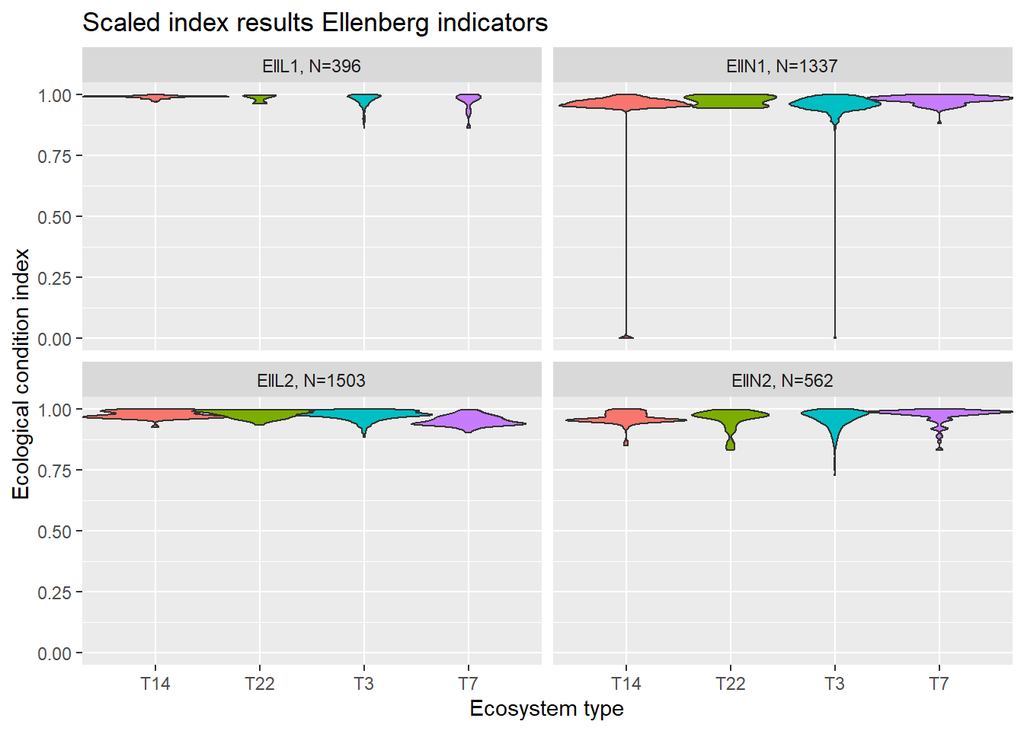

Ellenberg L shows most deviations from the reference value (index = 1) towards the higher limit value, Ellenberg N shows most deviations from the reference value towards the lower limit value (see N in the respective plot headers). However, the deviations are largely small and within the limits for good ecological condition (0.6 - 1).

Klikk here to see the next step in the analysis, aggregation and standardization of the indicator data set.